# Assignment 2: Random Forest

## Ralchukwu Mogbogu

### Assignment 2: Random Forest

### ANLY 530-50-A

### 12/3/2025

```
import pandas as pd
from sklearn import datasets
import numpy as np
```

```
import matplotlib.pyplot as plt
import seaborn as sns
```

```
credit = pd.read_csv('credit.csv')
```

```
print(credit.shape)
```

(30000, 25)

```
credit.info()

#info is showing that there is no missing data and there are 30000 instances within the variables
```

<class 'pandas.core.frame.DataFrame'>  
RangeIndex: 30000 entries, 0 to 29999  
Data columns (total 25 columns):  
# Column Non-Null Count Dtype  
--- ------ -------------- -----  
0 ID 30000 non-null int64  
1 LIMIT_BAL 30000 non-null int64  
2 SEX 30000 non-null int64  
3 EDUCATION 30000 non-null int64  
4 MARRIAGE 30000 non-null int64  
5 AGE 30000 non-null int64  
6 PAY_0 30000 non-null int64  
7 PAY_2 30000 non-null int64  
8 PAY_3 30000 non-null int64  
9 PAY_4 30000 non-null int64  
10 PAY_5 30000 non-null int64  
11 PAY_6 30000 non-null int64  
12 BILL_AMT1 30000 non-null int64  
13 BILL_AMT2 30000 non-null int64  
14 BILL_AMT3 30000 non-null int64  
15 BILL_AMT4 30000 non-null int64  
16 BILL_AMT5 30000 non-null int64  
17 BILL_AMT6 30000 non-null int64  
18 PAY_AMT1 30000 non-null int64  
19 PAY_AMT2 30000 non-null int64  
20 PAY_AMT3 30000 non-null int64  
21 PAY_AMT4 30000 non-null int64  
22 PAY_AMT5 30000 non-null int64  
23 PAY_AMT6 30000 non-null int64  
24 DEFAULT 30000 non-null int64  
dtypes: int64(25)  
memory usage: 5.7 MB

```
credit.head(10)
#target variable is "DEFAULT" as it captures the payment for next month
```

[interactive chart not shown]

```
credit.describe()
```

[interactive chart not shown]

```
credit.dtypes
```

[interactive chart not shown]

```
#Assign y to the “class” variable and X to the rest of the variables. Assuming "class" means target variable
X = credit.drop(['ID', 'DEFAULT'], axis = 1)
#all variables EXCEPT for the ID and Default variables, cause one is not needed and the other is the target
y = credit['DEFAULT']
```

```
#Split the data into 80% for training and 20% for test
from sklearn.model_selection import train_test_split
X_train, X_test, y_train, y_test = train_test_split(X, y, test_size=0.20,
random_state=52)
```

```
# Create a Random Forest model using training data
from sklearn.ensemble import RandomForestClassifier
clf = RandomForestClassifier()
clf.fit(X_train, y_train)
```

[interactive chart not shown]

```
#Test the model using Test data, show confusion matrix
from sklearn.metrics import confusion_matrix
y_predict = clf.predict(X_test)
confusion_matrix(y_test, y_predict)
```

[interactive chart not shown]

```
# Measure the accuracy
from sklearn.metrics import accuracy_score
accuracy_score(y_test, y_predict)*100
```

81.96666666666667

```
#Feature Importance
cols = X.columns.tolist()
feature_importances = pd.DataFrame(clf.feature_importances_, index = cols,
columns=['importance']).sort_values('importance', ascending=False)
feature_importances
```

[interactive chart not shown]

```
#Visualize Feature Importance
plt.figure(figsize=(10, 5))
sns.barplot(x= 'importance', y= feature_importances.index, data= feature_importances, palette='viridis')
plt.title('Important Features for Credit')
plt.ylabel('Explanatory Variables')
plt.show()
```

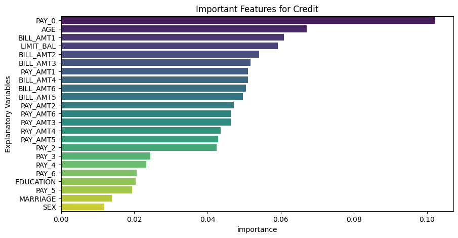

/tmp/ipykernel_481/3242833808.py:3: FutureWarning:  
Passing `palette` without assigning `hue` is deprecated and will be removed in v0.14.0. Assign the `y` variable to `hue` and set `legend=False` for the same effect.  
sns.barplot(x= 'importance', y= feature_importances.index, data= feature_importances, palette='viridis')

[figure not shown]